# End-to-end system identification: a user-defined model

This notebook takes a pharmacokinetic model from a plain Python function all the way to confidence intervals on its parameters, using a **user-defined** model.

The point is not that the fit succeeds. It is that **a good fit tells you almost nothing about whether your parameters are identifiable** — and that the toolbox will tell you the difference if you ask it.

A MATLAB Live Script version (`Examples/pk_user_defined.m`) runs the same computation with the same section numbering, so the two can be read side by side. Throughout, `# MATLAB:` comments give the equivalent toolbox call.

## The model

A one-compartment model with first-order absorption, the standard description of an orally administered drug:

$$c(t)=\frac{D\,k_a}{V(k_a-k_e)}\left(e^{-k_e t}-e^{-k_a t}\right)$$

Three factors are to be identified, with the dose $D=100$ mg known:

- $k_a$ — absorption rate constant (1/h)
- $k_e$ — elimination rate constant (1/h)
- $V$ — apparent volume of distribution (L)

**This is the whole model.** Everything below reaches it through the toolbox rather than calling it directly — `model.evaluate(...)`, the counterpart of MATLAB's `gsua_eval`.

```python
import warnings
warnings.filterwarnings("ignore")

import numpy as np
import pandas as pd
import matplotlib.pyplot as plt

from gsua_csb import (UserFunctionModel, design_matrix, uncertainty_analysis,
                      coverage_metric, parameter_estimation,
                      identifiability_analysis, profile_likelihood)

DOSE = 100.0        # administered dose (mg), known


def pk_absorption(params, t):
    """Plasma concentration after a single oral dose.

    params : (3,) array of [ka, ke, V]
        ka  absorption rate constant (1/h)
        ke  elimination rate constant (1/h)
        V   apparent volume of distribution (L)
    t : (n,) array of sampling times, in hours

    Returns
    -------
    (1, n) array -- one observed output over the n times. The leading axis is the
    output index: gsua_csb models always return (n_outputs, n_times), even for a
    single output, which is what makes `model.output` selection possible.

    MATLAB equivalent: Examples/pkAbsorptionModel.m.
    """
    ka, ke, V = params
    return ((DOSE * ka) / (V * (ka - ke)) * (np.exp(-ke * t) - np.exp(-ka * t)))[None, :]
```

## 1. Preparing the environment

`UserFunctionModel` wraps the function above into the object every other `gsua_csb` routine consumes — the counterpart of the summary table `T` that `gsua_dataprep` builds in MATLAB.

The $k_a$ bounds are deliberately kept above the $k_e$ bounds. At $k_a=k_e$ the closed form is singular, and swapping the two leaves $c(t)$ unchanged — the classic *flip-flop* ambiguity. Excluding it keeps this example about experimental design rather than an algebraic accident.

```python
# Factor bounds: one row per factor, [lower, upper] -- same layout as MATLAB's `ranges`.
ranges = np.array([[0.6,  3.0],     # ka  absorption rate (1/h)
                   [0.05, 0.5],     # ke  elimination rate (1/h)
                   [5.0,  40.0]])   # V   volume of distribution (L)

truth = np.array([1.2, 0.25, 15.0])                        # values to recover
xdata = np.array([0.25, 0.5, 1, 1.5, 2, 3, 4, 6, 8,
                  10, 12, 16, 20, 24.0])                   # sampling schedule (hours)

# MATLAB: [T,~] = gsua_dataprep('pkAbsorptionModel', ranges, 'domain',[0 24], ...)
model = UserFunctionModel(
    func=pk_absorption,          # <-- the model function defined above
    names=["ka", "ke", "V"],
    range=ranges,
    nominal=truth,
    domain=xdata,
    output_names=["concentration"],
)
print("factors:", model.names, "| free:", int((~model.fixed).sum()))
print("outputs:", model.active_output_names)
```

```
factors: ['ka', 'ke', 'V'] | free: 3
outputs: ['concentration']
```

## 2. Synthetic data

Working from synthetic data means the truth is known, so the confidence intervals can be *checked* rather than merely reported.

Note that the model is evaluated through `model.evaluate`, not by calling `pk_absorption` directly. That is the toolbox's evaluation path — it applies the model's output selection (see `model.output`) and matches what every routine below does internally. MATLAB's `gsua_eval` plays the same role.

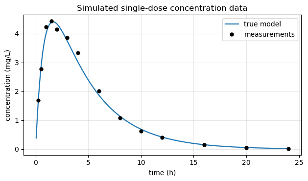

```python
rng = np.random.default_rng(0)                  # fix the noise draw so the page reproduces

# MATLAB: clean = gsua_eval(truth, T, xdata, [], false, false);
clean = model.evaluate(truth, xdata)            # noise-free model output at the sample times
ydata = clean * (1 + 0.08 * rng.standard_normal(clean.shape))   # 8% proportional noise

tdense = np.linspace(0.05, 24, 300)             # dense grid, for drawing curves only

plt.figure(figsize=(6.4, 3.8))
plt.plot(tdense, model.evaluate(truth, tdense)[0], lw=1.6, label="true model")
plt.plot(xdata, ydata[0], "ko", ms=5, label="measurements")
plt.xlabel("time (h)"); plt.ylabel("concentration (mg/L)")
plt.title("Simulated single-dose concentration data")
plt.legend(); plt.grid(alpha=.3); plt.tight_layout(); plt.show()
```

## 3. Can these parameters be estimated at all?

Before spending any optimizer budget it is worth asking whether the data is even *reachable*: does it fall inside the range of behaviours the model can produce over the bounds declared in section 1? If it does not, no amount of optimization will help — the model structure or the bounds are wrong, and that has to be fixed first. This is the reachability check that opens the toolbox's semi-automated identification cycle.

`design_matrix` samples the factor box and `uncertainty_analysis` runs the Monte-Carlo ensemble over those samples.

```python
# MATLAB: M0 = gsua_dmatrix(T,500);  Y0 = gsua_ua(M0,T,'xdata',xdata,'ynom',ydata);
M0 = design_matrix(model, 500, seed=0)          # 500 samples of the factor box
ua0 = uncertainty_analysis(model, M0, xdata=xdata, y_exp=ydata)

# coverage_metric reduces the ensemble to a 5-95% band and scores it.
# MATLAB: [cost_data,cost_band,P5,~,P95] = gsua_covmetric(Y0, ydata, 'margin',0.1);
cost_data, cost_band, p5, _, p95 = coverage_metric(ua0.Y, ydata, margin=0.1)
contained = float(np.mean((ydata >= p5) & (ydata <= p95)))

pd.DataFrame({"contained": [contained],
              "median_band_width": [float(np.median(p95 - p5))],
              "cost_data": [cost_data],
              "cost_band": [cost_band]}).round(4)
```

|  | contained | median_band_width | cost_data | cost_band |
| --- | --- | --- | --- | --- |
| 0 | 1.0 | 4.8627 | 127.5652 | 2.246380e+07 |

All of the data lies inside the reachable band, so estimation is worth attempting.

`cost_data` and `cost_band` are both far above 1 here, and that is expected rather than alarming: they are normalized against a tight tolerance and are meaningful as a *post-convergence* check (section 7), not as a pass/fail gate against a prior range this wide. The containment fraction is the number to read at this stage. The band is enormous — a median width of several mg/L against data that never exceeds 4.5 — which is what an uninformative prior looks like before any fitting.

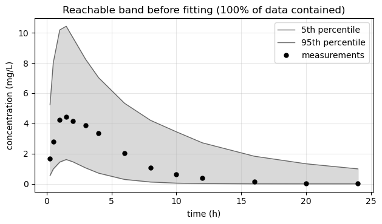

```python
plt.figure(figsize=(6.4, 3.8))
plt.plot(xdata, p5[0], color="0.4", lw=1, label="5th percentile")
plt.plot(xdata, p95[0], color="0.4", lw=1, label="95th percentile")
plt.fill_between(xdata, p5[0], p95[0], color="0.85")
plt.plot(xdata, ydata[0], "ko", ms=5, label="measurements")
plt.xlabel("time (h)"); plt.ylabel("concentration (mg/L)")
plt.title(f"Reachable band before fitting ({contained:.0%} of data contained)")
plt.legend(); plt.grid(alpha=.3); plt.tight_layout(); plt.show()
```

## 4. Estimating the parameters

`parameter_estimation` runs a multistart fit: `n=20` restarts the optimizer from twenty different points in the factor space, which is how you find out whether the problem has one solution or several.

```python
# margin=0.1 selects the correlation-penalized cost and records the margin on the
# result, so functions further down the pipeline can recover what was scored.
# MATLAB: [T3,res3] = gsua_pe(T, xdata, ydata, 'solver','lsqc', 'N',20, 'margin',0.1)
pe3 = parameter_estimation(model, xdata, ydata, n=20,
                           solver="least_squares", margin=0.1, seed=0)

best3 = pe3.x[np.argmin(pe3.cost)]              # pe3.x is (20, 3): one row per restart
pd.DataFrame({"true": truth, "estimated": best3.round(4)}, index=model.names)
```

|  | true | estimated |
| --- | --- | --- |
| ka | 1.20 | 1.1554 |
| ke | 0.25 | 0.2507 |
| V | 15.00 | 14.5982 |

```
cost across the 20 restarts:  min 0.18284   max 0.18284
```

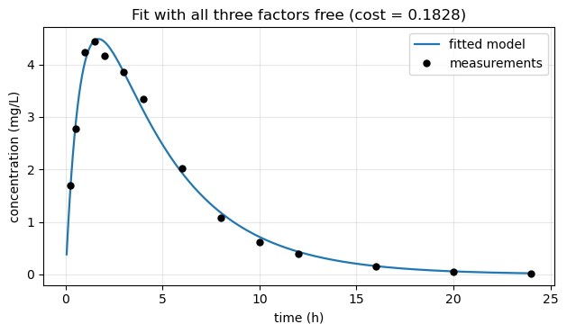

```python
print(f"cost across the 20 restarts:  min {pe3.cost.min():.5g}   max {pe3.cost.max():.5g}")

plt.figure(figsize=(6.4, 3.8))
plt.plot(tdense, model.evaluate(best3, tdense)[0], lw=1.6, label="fitted model")
plt.plot(xdata, ydata[0], "ko", ms=5, label="measurements")
plt.xlabel("time (h)"); plt.ylabel("concentration (mg/L)")
plt.title(f"Fit with all three factors free (cost = {pe3.cost.min():.4g})")
plt.legend(); plt.grid(alpha=.3); plt.tight_layout(); plt.show()
```

Every one of the twenty restarts converged to the same cost, and the fitted curve passes cleanly through the data. On most projects this is where the analysis would stop.

## 5. Diagnosing identifiability

The correlation between the repeated estimates is the first warning sign. Values near $\pm 1$ mean the factors trade off against each other: many different combinations reproduce the same curve.

```python
# MATLAB: array2table(corr(Est3'), ...)
ia3 = identifiability_analysis(model, pe3.x, cost=pe3.cost, cost_rtol=0.1, seed=0)
pd.DataFrame(ia3.correlation.round(4), index=model.names, columns=model.names)
```

|  | ka | ke | V |
| --- | --- | --- | --- |
| ka | 1.0000 | -0.9999 | 1.0 |
| ke | -0.9999 | 1.0000 | -1.0 |
| V | 1.0000 | -1.0000 | 1.0 |

```python
# profile_likelihood steps each factor away from the estimate while re-fitting all the
# others at every step, and reports where the fit stays statistically acceptable.
# margin is the assumed relative standard deviation: 0.08 matches the 8% noise above.
# MATLAB's gsua_likelihood offsets this by one, so the same run there is margin=1.08:
# MATLAB: gsua_likelihood(T3, xdata, ydata, 0.95, 0.05, 1.08, 0.01, 0.01, 15, 1, ...)
pl3 = profile_likelihood(model, xdata, ydata, alpha=0.95, margin=0.08)

pd.DataFrame({
    "CI_low":     pl3.range[:, 0].round(4),
    "CI_high":    pl3.range[:, 1].round(4),
    "width":      (pl3.range[:, 1] - pl3.range[:, 0]).round(4),
    "prior_low":  ranges[:, 0],
    "prior_high": ranges[:, 1],
}, index=model.names)
```

|  | CI_low | CI_high | width | prior_low | prior_high |
| --- | --- | --- | --- | --- | --- |
| ka | 0.9352 | 1.4798 | 0.5447 | 0.60 | 3.0 |
| ke | 0.2448 | 0.2709 | 0.0261 | 0.05 | 0.5 |
| V | 13.0391 | 16.4258 | 3.3867 | 5.00 | 40.0 |

This is the result worth stopping on. The correlation between $k_a$ and $k_e$ is essentially $-1$: the three factors cannot be separated from a single oral concentration curve, however well that curve fits. That is a textbook pharmacokinetic result, not a failure of the optimizer.

## 6. The remedy: fix what another experiment already knows

The standard resolution is to measure $V$ separately, in an intravenous study where it *is* directly identifiable, and then estimate only the two rate constants. A factor is fixed by giving it a degenerate range — lower bound equal to upper bound — which is what `Model.fix` does in place.

```python
import copy
model_fixed = copy.deepcopy(model)
model_fixed.fix("V", 15.0)                      # MATLAB: give the V row the range [15 15]
free = np.where(~model_fixed.fixed)[0]          # -> [0, 1], i.e. ka and ke
print("free factors now:", [model.names[i] for i in free])
```

```
free factors now: ['ka', 'ke']
```

```python
pe2 = parameter_estimation(model_fixed, xdata, ydata, n=20,
                           solver="least_squares", margin=0.1, seed=0)
best2 = pe2.x[np.argmin(pe2.cost)]
ia2 = identifiability_analysis(model_fixed, pe2.x, cost=pe2.cost, cost_rtol=0.1, seed=0)
pl2 = profile_likelihood(model_fixed, xdata, ydata, alpha=0.95, margin=0.08,
                         params=list(free))    # profile only the free factors

pd.DataFrame({
    "true":      truth[free],
    "estimated": best2[free].round(4),
    "CI_low":    pl2.range[free, 0].round(4),
    "CI_high":   pl2.range[free, 1].round(4),
    "width":     (pl2.range[free, 1] - pl2.range[free, 0]).round(4),
}, index=[model.names[i] for i in free])
```

[output not shown]

## 7. The two runs side by side

```python
pd.DataFrame({
    "all three free": [pe3.cost.min(), ia3.correlation[0, 1],
                       pl3.range[0, 1] - pl3.range[0, 0],
                       pl3.range[1, 1] - pl3.range[1, 0]],
    "V fixed":        [pe2.cost.min(), ia2.correlation[0, 1],
                       pl2.range[0, 1] - pl2.range[0, 0],
                       pl2.range[1, 1] - pl2.range[1, 0]],
}, index=["best cost", "corr(ka, ke)", "CI width ka", "CI width ke"]).round(4)
```

|  | all three free | V fixed |
| --- | --- | --- |
| best cost | 0.1828 | 0.1899 |
| corr(ka, ke) | -0.9999 | 0.3869 |
| CI width ka | 0.5447 | 0.4369 |
| CI width ke | 0.0261 | 0.0139 |

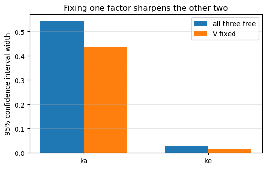

```python
x = np.arange(2); w = 0.35
plt.figure(figsize=(5.6, 3.6))
plt.bar(x - w/2, [pl3.range[i, 1] - pl3.range[i, 0] for i in range(2)], w, label="all three free")
plt.bar(x + w/2, [pl2.range[i, 1] - pl2.range[i, 0] for i in range(2)], w, label="V fixed")
plt.xticks(x, ["ka", "ke"]); plt.ylabel("95% confidence interval width")
plt.title("Fixing one factor sharpens the other two")
plt.legend(); plt.grid(alpha=.3, axis="y"); plt.tight_layout(); plt.show()
```

## 8. What this example shows

Cost measures how well a curve passes through points. It does not measure whether the factors that produced that curve could have been recovered. Only the identifiability analysis answers that, which is why it belongs *inside* the workflow rather than after it.

The companion symbolic-ODE example reaches the same conclusion from the opposite direction: there, the dataset that fits *better* is the one whose parameters are *less* identifiable.

Where a multistart run does spread across the factor space instead of converging to a single point, `identifiability_analysis` adds detection of multiple global minima, `noise_floor` calibrates which fits to accept against the observation noise, and `design_matrix(..., method="joint")` propagates the accepted set without destroying its correlation structure.